# TS Linear Model

Armando Torres Bejar

Fist of all, we need to transform all of our variables that we´re going to use into time series variables for accurtae outputs

```r
attach(ACT_IND_MEX)

Periodo <- ts(Periodo,frequency = 4, start = c(1993,1))
ai <- ts(ai,frequency = 4, start = c(1993,1))
y <- ts(y,frequency = 4, start = c(1993,1), end = c(2024,2))
inf <- ts(inf,frequency = 4, start = c(1993,1))
ied <- ts(ied,frequency = 4, start = c(1993,1))
r <- ts(r,frequency = 4, start = c(1993,1))
```

#### Descriptive Analysis

Variables:

- ai = Industrial Activity
- y = Gross Domestic Product
- inf = Inflation Rate
- ied = Foreign Direct Investment
- r = Interest Rate (CETES 91 days): Average Profit

```r
dat <- data.frame(vars, mean, variation, skew, kurtos)
dat[,2:5] <- round(dat[,2:5], digits = 2)
dat
```

```
##   vars    mean variation  skew kurtos
## 1   ai 8.8e+01   1.2e+02 -0.74    2.8
## 2    y 2.0e+07   1.1e+13 -0.22    2.0
## 3  inf 8.2e+00   7.4e+01  2.90   11.8
## 4  ied 6.4e+03   2.1e+07  1.93    7.5
## 5    r 1.1e+01   1.1e+02  2.66   11.6
```

```r
cor(ACT_IND_MEX[,c("ai","inf", "r")])
```

```
##        ai   inf     r
## ai   1.00 -0.65 -0.68
## inf -0.65  1.00  0.82
## r   -0.68  0.82  1.00
```

As the kurtosis is closer to 0, less skewness the variable has, in other words, a krtosis equal to 0 inidicates a normal distribution

#### Including Plots

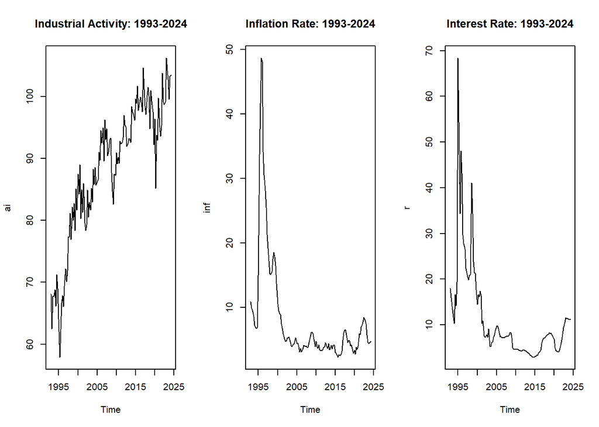

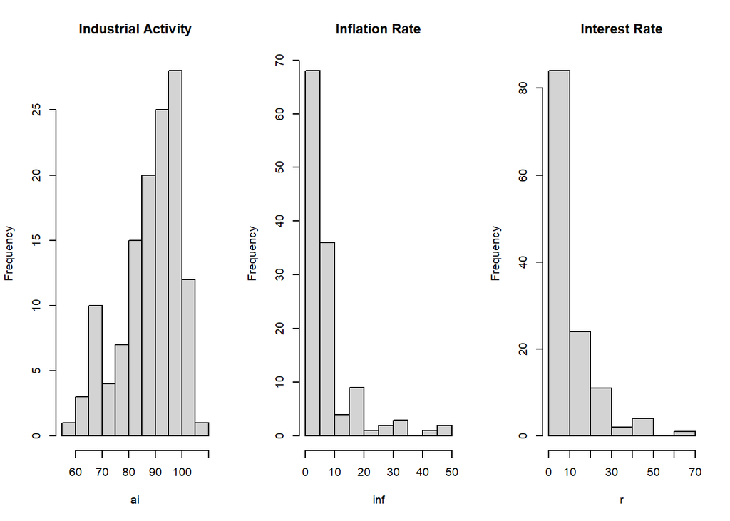

As a first step, we´d like to know if the series is stationary, which guarantees that the statistical properties in the time series don´t change over time.
For this, we´ll be evaluating each of the variables with the Augmented Dickey Fuller Test, this test evaluates if the time series has a unit root.
The presence of a unit root implies that the time series is non-stationary.
$$H_0: Non-stationary$$
The results interpretation focus in the Test statistical value compared to the Critical values, if Test statistical value < Critical value, we can reject the null hypothesis.
#### Estimate ADF test on the variables:

We´ll be evalating three different types of ADF test on our variables:

- With Trend and Intercept:
  - Tests whether the series is stationary around a deterministic trend.
- With Intercept Only:
  - Tests whether the series is stationary around a constant mean.
- Without Trend and Intercept:
  - Tests whether the series is stationary around 0.

$$\text{ADF test on variable: }
ai$$

Tests whether the series is stationary with trend and intercept:

```r
summary(ur.df(ai, type=c("trend"), lags = 8, selectlags=c("BIC")))
```

```
##
## ###############################################
## # Augmented Dickey-Fuller Test Unit Root Test #
## ###############################################
##
## Test regression trend
##
##
## Call:
## lm(formula = z.diff ~ z.lag.1 + 1 + tt + z.diff.lag)
##
## Residuals:
##    Min     1Q Median     3Q    Max
## -11.36  -1.31   0.12   1.50   6.86
##
## Coefficients:
##             Estimate Std. Error t value Pr(>|t|)
## (Intercept)  13.4347     4.2782    3.14  0.00217 **
## z.lag.1      -0.1744     0.0593   -2.94  0.00399 **
## tt            0.0383     0.0172    2.23  0.02776 *
## z.diff.lag1  -0.1574     0.0958   -1.64  0.10322
## z.diff.lag2  -0.0128     0.0887   -0.14  0.88560
## z.diff.lag3  -0.2892     0.0871   -3.32  0.00122 **
## z.diff.lag4   0.3254     0.0864    3.77  0.00027 ***
## ---
## Signif. codes:  0 '***' 0.001 '**' 0.01 '*' 0.05 '.' 0.1 ' ' 1
##
## Residual standard error: 2.7 on 110 degrees of freedom
## Multiple R-squared:  0.522,  Adjusted R-squared:  0.496
## F-statistic:   20 on 6 and 110 DF,  p-value: 1.04e-15
##
##
## Value of test-statistic is: -2.9 4.3 4.8
##
## Critical values for test statistics:
##      1pct 5pct 10pct
## tau3 -4.0 -3.4  -3.1
## phi2  6.2  4.8   4.1
## phi3  8.4  6.5   5.5
```

Non stationary due to the test result: -2.94 which isn’t smaller than the critical values.

Tests whether the series is stationary with intercept only:

```r
summary(ur.df(ai, type=c("drift"), lags = 8, selectlags=c("BIC")))
```

```
##
## ###############################################
## # Augmented Dickey-Fuller Test Unit Root Test #
## ###############################################
##
## Test regression drift
##
##
## Call:
## lm(formula = z.diff ~ z.lag.1 + 1 + z.diff.lag)
##
## Residuals:
##     Min      1Q  Median      3Q     Max
## -10.773  -1.296   0.121   1.619   6.844
##
## Coefficients:
##             Estimate Std. Error t value Pr(>|t|)
## (Intercept)   5.3838     2.3369    2.30  0.02310 *
## z.lag.1      -0.0551     0.0260   -2.12  0.03649 *
## z.diff.lag1  -0.2510     0.0877   -2.86  0.00502 **
## z.diff.lag2  -0.0816     0.0846   -0.96  0.33723
## z.diff.lag3  -0.3472     0.0846   -4.10  7.8e-05 ***
## z.diff.lag4   0.2945     0.0867    3.40  0.00095 ***
## ---
## Signif. codes:  0 '***' 0.001 '**' 0.01 '*' 0.05 '.' 0.1 ' ' 1
##
## Residual standard error: 2.7 on 111 degrees of freedom
## Multiple R-squared:   0.5,   Adjusted R-squared:  0.478
## F-statistic: 22.2 on 5 and 111 DF,  p-value: 2.18e-15
##
##
## Value of test-statistic is: -2.1 3.8
##
## Critical values for test statistics:
##      1pct 5pct 10pct
## tau2 -3.5 -2.9  -2.6
## phi1  6.5  4.6   3.8
```

Non stationary due to the test result: -2.11 which isn’t smaller than the critical values.

Tests whether the series is stationary without intercept:

```r
summary(ur.df(ai, type=c("none"), lags = 8, selectlags=c("BIC")))
```

```
##
## ###############################################
## # Augmented Dickey-Fuller Test Unit Root Test #
## ###############################################
##
## Test regression none
##
##
## Call:
## lm(formula = z.diff ~ z.lag.1 - 1 + z.diff.lag)
##
## Residuals:
##    Min     1Q Median     3Q    Max
## -11.11  -1.58   0.01   2.01   6.37
##
## Coefficients:
##             Estimate Std. Error t value Pr(>|t|)
## z.lag.1      0.00448    0.00298    1.50   0.1364
## z.diff.lag1 -0.27880    0.08848   -3.15   0.0021 **
## z.diff.lag2 -0.09638    0.08601   -1.12   0.2649
## z.diff.lag3 -0.35604    0.08611   -4.13  6.9e-05 ***
## z.diff.lag4  0.29720    0.08839    3.36   0.0011 **
## ---
## Signif. codes:  0 '***' 0.001 '**' 0.01 '*' 0.05 '.' 0.1 ' ' 1
##
## Residual standard error: 2.8 on 112 degrees of freedom
## Multiple R-squared:  0.481,  Adjusted R-squared:  0.458
## F-statistic: 20.7 on 5 and 112 DF,  p-value: 1.29e-14
##
##
## Value of test-statistic is: 1.5
##
## Critical values for test statistics:
##      1pct 5pct 10pct
## tau1 -2.6 -1.9  -1.6
```

Non stationary due to the test result: 1.5002 which isn’t smaller than the critical values.

At this point, due to the ADF test, we can not reject the null hypothesis of unit root in any test

$$\text{ADF test on variable: }
y$$

Tests whether the series is stationary with trend and intercept:

```r
summary(ur.df(y, type=c("trend"), lags = 8, selectlags=c("BIC")))
```

```
##
## ###############################################
## # Augmented Dickey-Fuller Test Unit Root Test #
## ###############################################
##
## Test regression trend
##
##
## Call:
## lm(formula = z.diff ~ z.lag.1 + 1 + tt + z.diff.lag)
##
## Residuals:
##      Min       1Q   Median       3Q      Max
## -4647202   -64629    65164   144195  1509949
##
## Coefficients:
##              Estimate Std. Error t value Pr(>|t|)
## (Intercept)  3.40e+06   9.25e+05    3.68  0.00036 ***
## z.lag.1     -2.30e-01   6.47e-02   -3.55  0.00057 ***
## tt           1.99e+04   5.95e+03    3.35  0.00110 **
## z.diff.lag  -6.38e-02   9.28e-02   -0.69  0.49323
## ---
## Signif. codes:  0 '***' 0.001 '**' 0.01 '*' 0.05 '.' 0.1 ' ' 1
##
## Residual standard error: 526000 on 113 degrees of freedom
## Multiple R-squared:  0.13,   Adjusted R-squared:  0.107
## F-statistic: 5.64 on 3 and 113 DF,  p-value: 0.00123
##
##
## Value of test-statistic is: -3.5 6 6.4
##
## Critical values for test statistics:
##      1pct 5pct 10pct
## tau3 -4.0 -3.4  -3.1
## phi2  6.2  4.8   4.1
## phi3  8.4  6.5   5.5
```

Tests whether the series is stationary with intercept only:

```r
summary(ur.df(y, type=c("drift"), lags = 8, selectlags=c("BIC")))
```

```
##
## ###############################################
## # Augmented Dickey-Fuller Test Unit Root Test #
## ###############################################
##
## Test regression drift
##
##
## Call:
## lm(formula = z.diff ~ z.lag.1 + 1 + z.diff.lag)
##
## Residuals:
##      Min       1Q   Median       3Q      Max
## -4577933   -78720    29904   141192  2098182
##
## Coefficients:
##              Estimate Std. Error t value Pr(>|t|)
## (Intercept)  4.97e+05   3.34e+05    1.49    0.139
## z.lag.1     -1.91e-02   1.64e-02   -1.17    0.245
## z.diff.lag  -1.70e-01   9.11e-02   -1.86    0.065 .
## ---
## Signif. codes:  0 '***' 0.001 '**' 0.01 '*' 0.05 '.' 0.1 ' ' 1
##
## Residual standard error: 549000 on 114 degrees of freedom
## Multiple R-squared:  0.0438, Adjusted R-squared:  0.027
## F-statistic: 2.61 on 2 and 114 DF,  p-value: 0.0781
##
##
## Value of test-statistic is: -1.2 3
##
## Critical values for test statistics:
##      1pct 5pct 10pct
## tau2 -3.5 -2.9  -2.6
## phi1  6.5  4.6   3.8
```

Non stationary due to the test result: -1.16 which isn’t smaller than the critical values.

Tests whether the series is stationary without intercept:

```r
summary(ur.df(y, type=c("none"), lags = 8, selectlags=c("BIC")))
```

```
##
## ###############################################
## # Augmented Dickey-Fuller Test Unit Root Test #
## ###############################################
##
## Test regression none
##
##
## Call:
## lm(formula = z.diff ~ z.lag.1 - 1 + z.diff.lag)
##
## Residuals:
##      Min       1Q   Median       3Q      Max
## -4652540   -62281    64743   148906  2099740
##
## Coefficients:
##            Estimate Std. Error t value Pr(>|t|)
## z.lag.1     0.00495    0.00253    1.96    0.053 .
## z.diff.lag -0.17718    0.09148   -1.94    0.055 .
## ---
## Signif. codes:  0 '***' 0.001 '**' 0.01 '*' 0.05 '.' 0.1 ' ' 1
##
## Residual standard error: 552000 on 115 degrees of freedom
## Multiple R-squared:  0.0534, Adjusted R-squared:  0.0369
## F-statistic: 3.24 on 2 and 115 DF,  p-value: 0.0427
##
##
## Value of test-statistic is: 2
##
## Critical values for test statistics:
##      1pct 5pct 10pct
## tau1 -2.6 -1.9  -1.6
```

The series seems to be stationary when considering trend,  
However, when considering only a drift or no deterministic component (no constant or trend), the series seems to be non stationary.

$$\text{ADF test on variable: }
inf$$
Tests whether the series is stationary with trend and intercept:

```r
summary(ur.df(inf, type=c("trend"), lags = 8, selectlags=c("BIC")))
```

```
##
## ###############################################
## # Augmented Dickey-Fuller Test Unit Root Test #
## ###############################################
##
## Test regression trend
##
##
## Call:
## lm(formula = z.diff ~ z.lag.1 + 1 + tt + z.diff.lag)
##
## Residuals:
##     Min      1Q  Median      3Q     Max
## -10.146  -0.782  -0.169   0.509  13.839
##
## Coefficients:
##             Estimate Std. Error t value Pr(>|t|)
## (Intercept)  1.64332    0.63578    2.58  0.01102 *
## z.lag.1     -0.10244    0.02616   -3.92  0.00015 ***
## tt          -0.01316    0.00681   -1.93  0.05576 .
## z.diff.lag   0.61275    0.06954    8.81  1.7e-14 ***
## ---
## Signif. codes:  0 '***' 0.001 '**' 0.01 '*' 0.05 '.' 0.1 ' ' 1
##
## Residual standard error: 2 on 113 degrees of freedom
## Multiple R-squared:  0.426,  Adjusted R-squared:  0.41
## F-statistic: 27.9 on 3 and 113 DF,  p-value: 1.41e-13
##
##
## Value of test-statistic is: -3.9 5.3 7.8
##
## Critical values for test statistics:
##      1pct 5pct 10pct
## tau3 -4.0 -3.4  -3.1
## phi2  6.2  4.8   4.1
## phi3  8.4  6.5   5.5
```

Stationary, we can reject the null hypothesis because the test result: -3.91 is smaller than the than the 5pct critical value. Therefore, this is a stationary variable with trending on the model.

Tests whether the series is stationary with intercept only:

```r
summary(ur.df(inf, type=c("drift"), lags = 8, selectlags=c("BIC")))
```

```
##
## ###############################################
## # Augmented Dickey-Fuller Test Unit Root Test #
## ###############################################
##
## Test regression drift
##
##
## Call:
## lm(formula = z.diff ~ z.lag.1 + 1 + z.diff.lag)
##
## Residuals:
##    Min     1Q Median     3Q    Max
## -6.821 -0.544 -0.099  0.301 13.941
##
## Coefficients:
##             Estimate Std. Error t value Pr(>|t|)
## (Intercept)   0.3704     0.2540    1.46    0.148
## z.lag.1      -0.0546     0.0225   -2.43    0.017 *
## z.diff.lag1   0.6809     0.0858    7.93  1.9e-12 ***
## z.diff.lag2  -0.0984     0.0956   -1.03    0.306
## z.diff.lag3   0.1499     0.0956    1.57    0.120
## z.diff.lag4  -0.4205     0.0956   -4.40  2.5e-05 ***
## z.diff.lag5   0.2267     0.0868    2.61    0.010 *
## ---
## Signif. codes:  0 '***' 0.001 '**' 0.01 '*' 0.05 '.' 0.1 ' ' 1
##
## Residual standard error: 1.9 on 110 degrees of freedom
## Multiple R-squared:   0.5,   Adjusted R-squared:  0.473
## F-statistic: 18.4 on 6 and 110 DF,  p-value: 1.1e-14
##
##
## Value of test-statistic is: -2.4 3
##
## Critical values for test statistics:
##      1pct 5pct 10pct
## tau2 -3.5 -2.9  -2.6
## phi1  6.5  4.6   3.8
```

Non stationary due to the test result: -2.42 which isn’t smaller than the critical values.

Tests whether the series is stationary without intercept:

```r
summary(ur.df(inf, type=c("none"), lags = 8, selectlags=c("BIC")))
```

```
##
## ###############################################
## # Augmented Dickey-Fuller Test Unit Root Test #
## ###############################################
##
## Test regression none
##
##
## Call:
## lm(formula = z.diff ~ z.lag.1 - 1 + z.diff.lag)
##
## Residuals:
##    Min     1Q Median     3Q    Max
## -7.331 -0.363  0.094  0.521 13.997
##
## Coefficients:
##             Estimate Std. Error t value Pr(>|t|)
## z.lag.1      -0.0308     0.0155   -1.98    0.050 *
## z.diff.lag1   0.6723     0.0861    7.81  3.5e-12 ***
## z.diff.lag2  -0.1104     0.0958   -1.15    0.252
## z.diff.lag3   0.1376     0.0957    1.44    0.153
## z.diff.lag4  -0.4325     0.0958   -4.52  1.6e-05 ***
## z.diff.lag5   0.2105     0.0866    2.43    0.017 *
## ---
## Signif. codes:  0 '***' 0.001 '**' 0.01 '*' 0.05 '.' 0.1 ' ' 1
##
## Residual standard error: 1.9 on 111 degrees of freedom
## Multiple R-squared:  0.491,  Adjusted R-squared:  0.464
## F-statistic: 17.9 on 6 and 111 DF,  p-value: 2.08e-14
##
##
## Value of test-statistic is: -2
##
## Critical values for test statistics:
##      1pct 5pct 10pct
## tau1 -2.6 -1.9  -1.6
```

Stationary, we can reject the null hypothesis because the test result: -1.98 is smaller than the than the 5pct critical value. Therefore, this is a stationary variable without intercept on the model.

The test suggests to use this variable with no transformation due to the results regarding to the ADF test, which demonstrates that the variable is stationary without intercept and with trend and intercept.

$$\text{ADF test on variable: }
ied$$
Tests whether the series is stationary with trend and intercept:

```r
summary(ur.df(ied, type=c("trend"), lags = 8, selectlags=c("BIC")))
```

```
##
## ###############################################
## # Augmented Dickey-Fuller Test Unit Root Test #
## ###############################################
##
## Test regression trend
##
##
## Call:
## lm(formula = z.diff ~ z.lag.1 + 1 + tt + z.diff.lag)
##
## Residuals:
##    Min     1Q Median     3Q    Max
##  -7368  -1413   -398    948  13351
##
## Coefficients:
##              Estimate Std. Error t value Pr(>|t|)
## (Intercept) 3027.1380   969.6699    3.12  0.00231 **
## z.lag.1       -0.9802     0.3039   -3.23  0.00167 **
## tt            53.7415    19.8833    2.70  0.00800 **
## z.diff.lag1   -0.1196     0.2759   -0.43  0.66561
## z.diff.lag2   -0.2514     0.2543   -0.99  0.32513
## z.diff.lag3   -0.2566     0.2347   -1.09  0.27667
## z.diff.lag4    0.1234     0.2179    0.57  0.57234
## z.diff.lag5   -0.0384     0.1881   -0.20  0.83875
## z.diff.lag6   -0.1459     0.1478   -0.99  0.32596
## z.diff.lag7   -0.3715     0.1018   -3.65  0.00041 ***
## ---
## Signif. codes:  0 '***' 0.001 '**' 0.01 '*' 0.05 '.' 0.1 ' ' 1
##
## Residual standard error: 3010 on 107 degrees of freedom
## Multiple R-squared:  0.792,  Adjusted R-squared:  0.774
## F-statistic: 45.2 on 9 and 107 DF,  p-value: <2e-16
##
##
## Value of test-statistic is: -3.2 4 5.4
##
## Critical values for test statistics:
##      1pct 5pct 10pct
## tau3 -4.0 -3.4  -3.1
## phi2  6.2  4.8   4.1
## phi3  8.4  6.5   5.5
```

Tests whether the series is stationary with intercept only:

```r
summary(ur.df(ied, type=c("drift"), lags = 8, selectlags=c("BIC")))
```

```
##
## ###############################################
## # Augmented Dickey-Fuller Test Unit Root Test #
## ###############################################
##
## Test regression drift
##
##
## Call:
## lm(formula = z.diff ~ z.lag.1 + 1 + z.diff.lag)
##
## Residuals:
##    Min     1Q Median     3Q    Max
##  -9244  -1427   -320   1154  14247
##
## Coefficients:
##              Estimate Std. Error t value Pr(>|t|)
## (Intercept) 1824.8747   886.4216    2.06   0.0419 *
## z.lag.1       -0.2332     0.1301   -1.79   0.0757 .
## z.diff.lag1   -0.7671     0.1408   -5.45  3.2e-07 ***
## z.diff.lag2   -0.8116     0.1516   -5.35  4.9e-07 ***
## z.diff.lag3   -0.7222     0.1640   -4.40  2.5e-05 ***
## z.diff.lag4   -0.2548     0.1719   -1.48   0.1410
## z.diff.lag5   -0.3381     0.1563   -2.16   0.0327 *
## z.diff.lag6   -0.3549     0.1296   -2.74   0.0072 **
## z.diff.lag7   -0.4850     0.0953   -5.09  1.5e-06 ***
## ---
## Signif. codes:  0 '***' 0.001 '**' 0.01 '*' 0.05 '.' 0.1 ' ' 1
##
## Residual standard error: 3100 on 108 degrees of freedom
## Multiple R-squared:  0.777,  Adjusted R-squared:  0.761
## F-statistic: 47.2 on 8 and 108 DF,  p-value: <2e-16
##
##
## Value of test-statistic is: -1.8 2.2
##
## Critical values for test statistics:
##      1pct 5pct 10pct
## tau2 -3.5 -2.9  -2.6
## phi1  6.5  4.6   3.8
```

Tests whether the series is stationary without intercept:

```r
summary(ur.df(ied, type=c("none"), lags = 8, selectlags=c("BIC")))
```

```
##
## ###############################################
## # Augmented Dickey-Fuller Test Unit Root Test #
## ###############################################
##
## Test regression none
##
##
## Call:
## lm(formula = z.diff ~ z.lag.1 - 1 + z.diff.lag)
##
## Residuals:
##    Min     1Q Median     3Q    Max
##  -9097  -1149    158   1346  14514
##
## Coefficients:
##             Estimate Std. Error t value Pr(>|t|)
## z.lag.1       0.0198     0.0431    0.46   0.6465
## z.diff.lag1  -0.9820     0.0959  -10.24  < 2e-16 ***
## z.diff.lag2  -0.9879     0.1270   -7.78  4.5e-12 ***
## z.diff.lag3  -0.8590     0.1521   -5.65  1.3e-07 ***
## z.diff.lag4  -0.3549     0.1673   -2.12   0.0362 *
## z.diff.lag5  -0.4163     0.1538   -2.71   0.0079 **
## z.diff.lag6  -0.4053     0.1291   -3.14   0.0022 **
## z.diff.lag7  -0.5114     0.0959   -5.33  5.3e-07 ***
## ---
## Signif. codes:  0 '***' 0.001 '**' 0.01 '*' 0.05 '.' 0.1 ' ' 1
##
## Residual standard error: 3150 on 109 degrees of freedom
## Multiple R-squared:  0.769,  Adjusted R-squared:  0.752
## F-statistic: 45.3 on 8 and 109 DF,  p-value: <2e-16
##
##
## Value of test-statistic is: 0.46
##
## Critical values for test statistics:
##      1pct 5pct 10pct
## tau1 -2.6 -1.9  -1.6
```

Non stationary due to the test result: 0.45 which isn’t smaller than the critical values.

Due to the ADF test, we can not reject the null hypothesis of unit root in any test

$$\text{ADF test on variable: } r$$
Tests whether the series is stationary with trend and intercept:

```r
summary(ur.df(r, type=c("trend"), lags = 8, selectlags=c("BIC")))
```

```
##
## ###############################################
## # Augmented Dickey-Fuller Test Unit Root Test #
## ###############################################
##
## Test regression trend
##
##
## Call:
## lm(formula = z.diff ~ z.lag.1 + 1 + tt + z.diff.lag)
##
## Residuals:
##    Min     1Q Median     3Q    Max
## -6.357 -0.635 -0.171  0.551 22.217
##
## Coefficients:
##             Estimate Std. Error t value Pr(>|t|)
## (Intercept)  1.15233    0.98416    1.17   0.2442
## z.lag.1     -0.14029    0.03366   -4.17  6.1e-05 ***
## tt          -0.00161    0.00982   -0.16   0.8704
## z.diff.lag1 -0.15010    0.05024   -2.99   0.0035 **
## z.diff.lag2 -0.25866    0.04550   -5.69  1.1e-07 ***
## z.diff.lag3  0.13869    0.04543    3.05   0.0028 **
## ---
## Signif. codes:  0 '***' 0.001 '**' 0.01 '*' 0.05 '.' 0.1 ' ' 1
##
## Residual standard error: 2.6 on 111 degrees of freedom
## Multiple R-squared:  0.558,  Adjusted R-squared:  0.538
## F-statistic:   28 on 5 and 111 DF,  p-value: <2e-16
##
##
## Value of test-statistic is: -4.2 12 16
##
## Critical values for test statistics:
##      1pct 5pct 10pct
## tau3 -4.0 -3.4  -3.1
## phi2  6.2  4.8   4.1
## phi3  8.4  6.5   5.5
```

Tests whether the series is stationary with intercept only:

```r
summary(ur.df(r, type=c("drift"), lags = 8, selectlags=c("BIC")))
```

```
##
## ###############################################
## # Augmented Dickey-Fuller Test Unit Root Test #
## ###############################################
##
## Test regression drift
##
##
## Call:
## lm(formula = z.diff ~ z.lag.1 + 1 + z.diff.lag)
##
## Residuals:
##    Min     1Q Median     3Q    Max
## -6.353 -0.624 -0.155  0.512 22.253
##
## Coefficients:
##             Estimate Std. Error t value Pr(>|t|)
## (Intercept)   1.0026     0.3602    2.78   0.0063 **
## z.lag.1      -0.1365     0.0243   -5.62  1.4e-07 ***
## z.diff.lag1  -0.1530     0.0469   -3.26   0.0015 **
## z.diff.lag2  -0.2607     0.0435   -5.99  2.6e-08 ***
## z.diff.lag3   0.1373     0.0444    3.09   0.0025 **
## ---
## Signif. codes:  0 '***' 0.001 '**' 0.01 '*' 0.05 '.' 0.1 ' ' 1
##
## Residual standard error: 2.6 on 112 degrees of freedom
## Multiple R-squared:  0.558,  Adjusted R-squared:  0.542
## F-statistic: 35.3 on 4 and 112 DF,  p-value: <2e-16
##
##
## Value of test-statistic is: -5.6 18
##
## Critical values for test statistics:
##      1pct 5pct 10pct
## tau2 -3.5 -2.9  -2.6
## phi1  6.5  4.6   3.8
```

Tests whether the series is stationary without intercept:

```r
summary(ur.df(r, type=c("none"), lags = 8, selectlags=c("BIC")))
```

```
##
## ###############################################
## # Augmented Dickey-Fuller Test Unit Root Test #
## ###############################################
##
## Test regression none
##
##
## Call:
## lm(formula = z.diff ~ z.lag.1 - 1 + z.diff.lag)
##
## Residuals:
##    Min     1Q Median     3Q    Max
## -6.769  0.065  0.478  1.010 22.216
##
## Coefficients:
##             Estimate Std. Error t value Pr(>|t|)
## z.lag.1      -0.0860     0.0166   -5.17  1.0e-06 ***
## z.diff.lag1  -0.1884     0.0464   -4.06  9.2e-05 ***
## z.diff.lag2  -0.2865     0.0438   -6.54  1.8e-09 ***
## z.diff.lag3   0.1207     0.0453    2.66   0.0088 **
## ---
## Signif. codes:  0 '***' 0.001 '**' 0.01 '*' 0.05 '.' 0.1 ' ' 1
##
## Residual standard error: 2.7 on 113 degrees of freedom
## Multiple R-squared:  0.535,  Adjusted R-squared:  0.518
## F-statistic: 32.5 on 4 and 113 DF,  p-value: <2e-16
##
##
## Value of test-statistic is: -5.2
##
## Critical values for test statistics:
##      1pct 5pct 10pct
## tau1 -2.6 -1.9  -1.6
```

We can reject the null hypothesis of unit root.

#### Estimate ADF test on the differentiated variables:

$$\text{ADF test on variable: }
dai$$
Tests whether the series is stationary with trend and intercept:

```r
summary(ur.df(dai, type=c("trend"), lags = 8, selectlags=c("BIC")))
```

```
##
## ###############################################
## # Augmented Dickey-Fuller Test Unit Root Test #
## ###############################################
##
## Test regression trend
##
##
## Call:
## lm(formula = z.diff ~ z.lag.1 + 1 + tt + z.diff.lag)
##
## Residuals:
##     Min      1Q  Median      3Q     Max
## -10.795  -1.484   0.004   1.892   6.474
##
## Coefficients:
##             Estimate Std. Error t value Pr(>|t|)
## (Intercept)  1.24892    0.58004    2.15   0.0335 *
## z.lag.1     -1.56296    0.24845   -6.29  6.6e-09 ***
## tt          -0.01046    0.00763   -1.37   0.1731
## z.diff.lag1  0.22711    0.19242    1.18   0.2404
## z.diff.lag2  0.09909    0.14544    0.68   0.4971
## z.diff.lag3 -0.25932    0.08738   -2.97   0.0037 **
## ---
## Signif. codes:  0 '***' 0.001 '**' 0.01 '*' 0.05 '.' 0.1 ' ' 1
##
## Residual standard error: 2.7 on 110 degrees of freedom
## Multiple R-squared:  0.837,  Adjusted R-squared:  0.829
## F-statistic:  113 on 5 and 110 DF,  p-value: <2e-16
##
##
## Value of test-statistic is: -6.3 13 20
##
## Critical values for test statistics:
##      1pct 5pct 10pct
## tau3 -4.0 -3.4  -3.1
## phi2  6.2  4.8   4.1
## phi3  8.4  6.5   5.5
```

Tests whether the series is stationary with intercept only:

```r
summary(ur.df(dai, type=c("drift"), lags = 8, selectlags=c("BIC")))
```

```
##
## ###############################################
## # Augmented Dickey-Fuller Test Unit Root Test #
## ###############################################
##
## Test regression drift
##
##
## Call:
## lm(formula = z.diff ~ z.lag.1 + 1 + z.diff.lag)
##
## Residuals:
##     Min      1Q  Median      3Q     Max
## -11.182  -1.477  -0.044   1.820   6.198
##
## Coefficients:
##             Estimate Std. Error t value Pr(>|t|)
## (Intercept)   0.5409     0.2652    2.04   0.0438 *
## z.lag.1      -1.5217     0.2476   -6.15  1.3e-08 ***
## z.diff.lag1   0.1986     0.1921    1.03   0.3033
## z.diff.lag2   0.0813     0.1454    0.56   0.5773
## z.diff.lag3  -0.2694     0.0874   -3.08   0.0026 **
## ---
## Signif. codes:  0 '***' 0.001 '**' 0.01 '*' 0.05 '.' 0.1 ' ' 1
##
## Residual standard error: 2.7 on 111 degrees of freedom
## Multiple R-squared:  0.834,  Adjusted R-squared:  0.828
## F-statistic:  139 on 4 and 111 DF,  p-value: <2e-16
##
##
## Value of test-statistic is: -6.1 19
##
## Critical values for test statistics:
##      1pct 5pct 10pct
## tau2 -3.5 -2.9  -2.6
## phi1  6.5  4.6   3.8
```

Tests whether the series is stationary without intercept:

```r
summary(ur.df(dai, type=c("none"), lags = 8, selectlags=c("BIC")))
```

```
##
## ###############################################
## # Augmented Dickey-Fuller Test Unit Root Test #
## ###############################################
##
## Test regression none
##
##
## Call:
## lm(formula = z.diff ~ z.lag.1 - 1 + z.diff.lag)
##
## Residuals:
##     Min      1Q  Median      3Q     Max
## -10.508  -1.037   0.357   2.359   6.752
##
## Coefficients:
##             Estimate Std. Error t value Pr(>|t|)
## z.lag.1      -1.3792     0.2409   -5.73  8.7e-08 ***
## z.diff.lag1   0.0955     0.1879    0.51  0.61237
## z.diff.lag2   0.0108     0.1432    0.08  0.94015
## z.diff.lag3  -0.3079     0.0866   -3.56  0.00055 ***
## ---
## Signif. codes:  0 '***' 0.001 '**' 0.01 '*' 0.05 '.' 0.1 ' ' 1
##
## Residual standard error: 2.8 on 112 degrees of freedom
## Multiple R-squared:  0.828,  Adjusted R-squared:  0.821
## F-statistic:  134 on 4 and 112 DF,  p-value: <2e-16
##
##
## Value of test-statistic is: -5.7
##
## Critical values for test statistics:
##      1pct 5pct 10pct
## tau1 -2.6 -1.9  -1.6
```